# Tracksuit Survey Allocation Optimisation

Cai Yahui

2026-03-07

# Problem Overview

Tracksuit runs monthly brand tracking surveys across multiple categories.

Each category requires approximately **200 qualified respondents per month**.

However, categories vary in:

- incidence rate (probability of qualifying)
- survey length

Additionally:

- the mean survey length must remain **below 480 seconds**
- the goal is to **minimise the number of respondents surveyed**

This report explores an algorithmic approach to allocating category qualifiers into survey structures.

# Load Data

```r
categories <- read_csv("../data/fake_category_data.csv")
categories <- categories %>%
  mutate(
    expected_time = incidence_rate * category_length_seconds,
    required_exposures = ceiling(200 / incidence_rate)
  )

head(categories)
```

```
## # A tibble: 6 × 6
##   category_id category_name  incidence_rate category_length_seco…¹ expected_time
##         <dbl> <chr>                   <dbl>                  <dbl>         <dbl>
## 1           1 Fertility or …         0.0956                  165.          15.7
## 2           2 Big and Tall …         0.131                    69.8          9.16
## 3           4 Self Tan (Fem…         0.191                   116.          22.2
## 4           5 Baby Feeding           0.198                   166.          33.0
## 5           6 Baby products          0.188                    60.3         11.3
## 6           7 Online Health…         0.227                   165.          37.4
## # ℹ abbreviated name: ¹category_length_seconds
## # ℹ 1 more variable: required_exposures <dbl>
```

We calculate the expected time contribution of each category:

$$expected\_time_i = incidence\_rate_i
\times category\_length\_seconds_i$$

# Baseline Method - Greedy Packing

The baseline approach treats the problem as a **bin-packing optimisation** problem.

Categories are packed into survey bundles while ensuring:

$$Total\ expected\ time \leq 480\
seconds$$
.

```r
pack_greedy <- function(categories, max_time = 480){

  categories <- categories %>%
    arrange(desc(expected_time))

  surveys <- list()
  survey_time <- c()

  for(i in 1:nrow(categories)){

    cat <- categories[i,]
    placed <- FALSE

    for(j in seq_along(surveys)){

      if(survey_time[j] + cat$expected_time <= max_time){

        surveys[[j]] <- c(surveys[[j]], cat$category_id)
        survey_time[j] <- survey_time[j] + cat$expected_time
        placed <- TRUE
        break
      }
    }

    if(!placed){
      surveys[[length(surveys)+1]] <- c(cat$category_id)
      survey_time <- c(survey_time, cat$expected_time)
    }

  }

  surveys
}

greedy_design <- pack_greedy(categories)

greedy_design
```

```
## [[1]]
## [1] 69 71 77 53
##
## [[2]]
## [1] 73 66 78 62  8
##
## [[3]]
## [1] 50 64 60 68 76 51
##
## [[4]]
## [1] 47 42 54 59 74 44 52  2
##
## [[5]]
## [1] 38 30 75 40 36 72 65 43
##
## [[6]]
##  [1] 46 19 37 67 22 49 61 45 16 48
##
## [[7]]
##  [1] 63 58 18 21 34 33 41  7 32 70 24 29
##
## [[8]]
##  [1] 55  5 17 10 14 27 57  9 20 31 15 56  4 35 26 23 39 12
##
## [[9]]
## [1]  1 25 13 28  6 11
```

# Improved Method – Demand Weighted Packing

The greedy algorithm does not consider how many respondents are required for each category.

Categories with **low incidence rates require more respondents** to reach the quota.

To address this, we introduce a priority score:

$$priority_i = required\_exposures_i
\times expected\_time_i$$

This prioritises categories that both: - require many respondents - contribute significant survey time

```r
categories <- categories %>%
  mutate(priority = required_exposures * expected_time)

pack_weighted <- function(categories, max_time = 480){

  categories <- categories %>%
    arrange(desc(priority))

  surveys <- list()
  survey_time <- c()

  for(i in 1:nrow(categories)){

    cat <- categories[i,]
    placed <- FALSE

    for(j in seq_along(surveys)){

      if(survey_time[j] + cat$expected_time <= max_time){

        surveys[[j]] <- c(surveys[[j]], cat$category_id)
        survey_time[j] <- survey_time[j] + cat$expected_time
        placed <- TRUE
        break
      }
    }

    if(!placed){

      surveys[[length(surveys)+1]] <- c(cat$category_id)
      survey_time <- c(survey_time, cat$expected_time)

    }
  }

  surveys
}

weighted_design <- pack_weighted(categories)

weighted_design
```

```
## [[1]]
## [1] 19  8 22 62  5  7  1 77  4
##
## [[2]]
## [1] 71 30 78 53 36 15
##
## [[3]]
## [1] 73 42 38 47 44 21 14  2
##
## [[4]]
## [1] 16 69 50 40 18 51  9
##
## [[5]]
## [1] 37 60 24 66 43 10 33 45 20
##
## [[6]]
## [1] 46 59 17 34 32 68 76 52 27
##
## [[7]]
## [1] 49 64 54 41 61 29 74 31 72
##
## [[8]]
##  [1] 75 65 58 63 26 67 55 23 12  6 35 13 25 39 57 11
##
## [[9]]
## [1] 70 56 48 28
```

# Linear Programming

While heuristic methods such as greedy packing are computationally efficient, they do not guarantee an optimal allocation.

To further improve the solution, we formulate the problem as an optimisation task using **Linear Programming (LP)**.

The objective is to minimise the total number of respondents required while ensuring that each category receives at least 200 qualified respondents.

The expected number of qualified respondents for a category is:

$$qualified_i = respondents_i \times
incidence_rate_i$$

Therefore the minimum respondents required is:

$$respondents \geq 200 /
incidence\_rate$$

This optimisation provides a theoretical lower bound for the number of respondents required.

```r
categories <- categories %>%
  mutate(
    required_respondents = ceiling(200 / incidence_rate)
  )
```

The LP problem can be expressed as:

Minimise:

total respondents

Subject to:

```r
solve_lp <- function(categories){

  n <- nrow(categories)

  objective <- rep(1, n)

  constraint_matrix <- diag(categories$incidence_rate)

  constraint_dir <- rep(">=", n)

  constraint_rhs <- rep(200, n)

  solution <- lp(
    direction = "min",
    objective.in = objective,
    const.mat = constraint_matrix,
    const.dir = constraint_dir,
    const.rhs = constraint_rhs
  )

  solution$solution
}

lp_result <- solve_lp(categories)

lp_result
```

```
##  [1] 2091.5942 1524.0246 1046.5950 1007.8067 1063.0798  881.9957  730.3030
##  [8]  854.5064  795.0617  817.4468  742.0168  827.4336  862.3701  662.3967
## [15]  622.6496  639.4737  643.0279  655.8952  638.8262  688.4696  655.2174
## [22]  648.3740  726.8908  624.1667  647.2946  570.8502  484.8073  498.6364
## [29]  506.9565  611.6071  550.6744  598.2022  503.4068  533.3333  511.9675
## [36]  478.6667  470.4861  486.5832  453.4783  463.8298  434.1847  485.6589
## [43]  450.9960  469.8901  399.2263  412.1212  404.8964  411.6000  318.8000
## [50]  359.1753  312.8631  345.4175  289.2704  401.7021  349.8998  296.2199
## [57]  349.9014  327.4262  324.0076  374.4681  379.7895  326.8022  235.4430
## [64]  280.7302  232.7928  252.7514  267.2131  225.9442  235.6303  253.8310
## [71]  273.6402  249.0421  250.1767  253.0165  271.2871  260.7646  292.1569
```

The LP solution estimates the minimum number of respondents required for each category to achieve 200 qualified responses in expectation.

However, because qualification is probabilistic, the LP result represents a **theoretical lower bound** rather than a guaranteed solution.

# Simulation Validation

Because qualification is probabilistic, we validate the policy using Monte Carlo simulation.

```r
run_simulation <- function(categories, survey_design, n_runs = 500){

  map_dfr(1:n_runs, function(run){

    qualified_counts <- rep(0, nrow(categories))
    names(qualified_counts) <- categories$category_id

    total_time <- 0
    respondents <- 0

    while(any(qualified_counts < 200)){

      respondents <- respondents + 1

      survey <- survey_design[[sample(1:length(survey_design),1)]]

      for(cat in survey){

        inc <- categories$incidence_rate[
          categories$category_id == cat
        ]

        length <- categories$category_length_seconds[
          categories$category_id == cat
        ]

        qualify <- rbinom(1,1,inc)

        if(qualify==1){

          qualified_counts[as.character(cat)] <-
            qualified_counts[as.character(cat)] + 1

          total_time <- total_time + length
        }

      }

    }

    tibble(
      respondents = respondents,
      avg_time = total_time/respondents
    )

  })
}
```

```r
greedy_results <- run_simulation(categories, greedy_design)

weighted_results <- run_simulation(categories, weighted_design)
```

## Simulation Using LP Baseline

```r
simulate_lp <- function(categories, n_runs = 500){

  map_dfr(1:n_runs, function(run){

    respondents <- ceiling(max(200/categories$incidence_rate))

    qualified <- rbinom(
      nrow(categories),
      respondents,
      categories$incidence_rate
    )

    tibble(
      respondents = respondents,
      success = all(qualified >= 200)
    )

  })
}

lp_sim <- simulate_lp(categories)

lp_sim
```

```
## # A tibble: 500 × 2
##    respondents success
##          <dbl> <lgl>
##  1        2092 TRUE
##  2        2092 TRUE
##  3        2092 TRUE
##  4        2092 TRUE
##  5        2092 TRUE
##  6        2092 TRUE
##  7        2092 FALSE
##  8        2092 TRUE
##  9        2092 FALSE
## 10        2092 TRUE
## # ℹ 490 more rows
```

```r
comparison <- tibble(
  method = c("Greedy","Weighted","LP lower bound"),
  respondents = c(
    mean(greedy_results$respondents),
    mean(weighted_results$respondents),
    mean(lp_sim$respondents)
  )
)

comparison
```

```
## # A tibble: 3 × 2
##   method         respondents
##   <chr>                <dbl>
## 1 Greedy              18760.
## 2 Weighted            18783.
## 3 LP lower bound       2092
```

# Visualisation

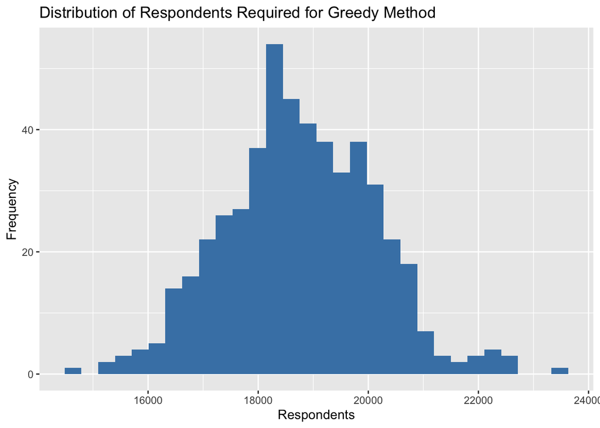

```r
ggplot(greedy_results, aes(respondents)) +
  geom_histogram(bins=30, fill="steelblue") +
  labs(
    title="Distribution of Respondents Required for Greedy Method",
    x="Respondents",
    y="Frequency"
  )
```

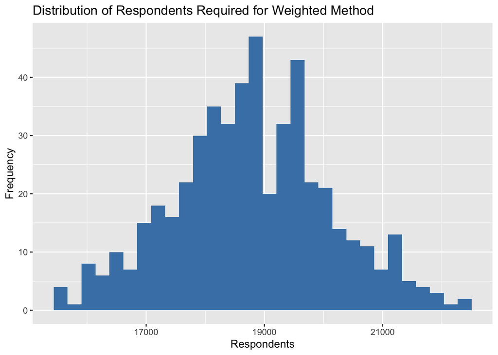

```r
ggplot(weighted_results, aes(respondents)) +
  geom_histogram(bins=30, fill="steelblue") +
  labs(
    title="Distribution of Respondents Required for Weighted Method",
    x="Respondents",
    y="Frequency"
  )
```

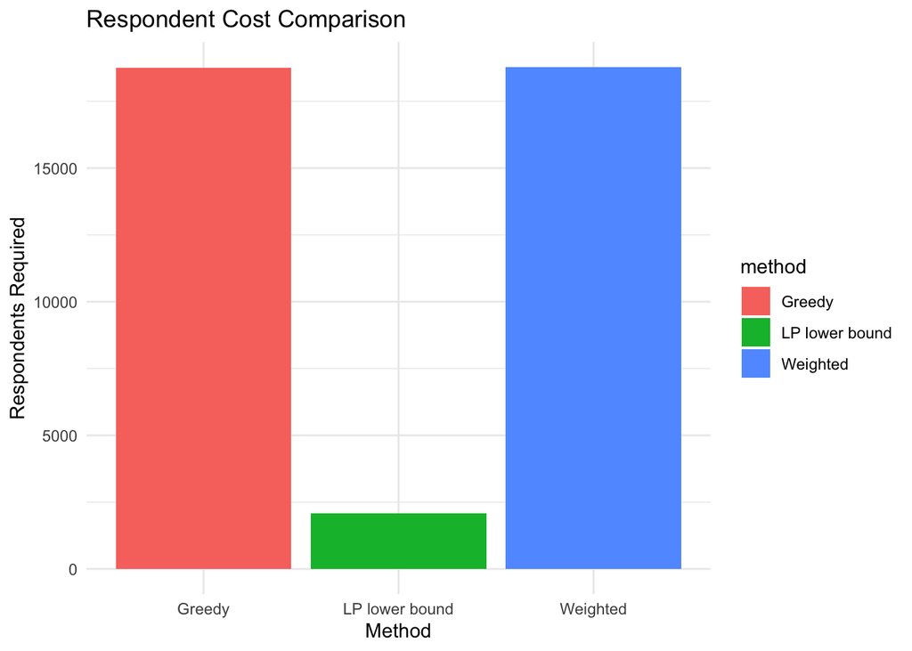

```r
ggplot(comparison, aes(method, respondents, fill = method)) +
  geom_bar(stat="identity") +
  labs(
    title="Respondent Cost Comparison",
    x="Method",
    y="Respondents Required"
  ) +
  theme_minimal()
```

# Survey Length Validation

The simulation confirms that the expected interview length remains below the 480 second constraint.

```r
mean(greedy_results$avg_time)
```

```
## [1] 433.2689
```

```r
mean(weighted_results$avg_time)
```

```
## [1] 433.3623
```

## Why Compare These Approaches?

Greedy packing  
Simple heuristic that prioritises categories with large expected survey time.

Linear Programming baseline  
Provides a theoretical lower bound for the number of respondents required.

# Real-World Considerations

Several extensions could further improve this system:

1. **Incidence uncertainty**

Estimated incidence rates may differ from real values.

2. **Adaptive allocation**

Survey allocation could be dynamically adjusted during the month.

3. **Audience clustering**

Categories with similar audiences could potentially be grouped together to increase qualification efficiency. However, this approach risks introducing demographic bias and would require careful validation.

# Conclusion

This project demonstrates a scalable approach to survey allocation by combining:

- heuristic optimisation
- demand-aware prioritisation
- Linear Programming Optimisation
- Monte Carlo simulation

**Note** : Because qualification events are stochastic (Bernoulli trials), quota fulfilment becomes a stopping-time process. As a result, simulation is required to evaluate the probabilistic performance of each allocation strategy.